# Data 621 Homework 3: Insurance

Tommy Jenkins, Violeta Stoyanova, Todd Weigel, Peter Kowalchuk, Eleanor R-Secoquian, Anthony Pagan

November 6, 2019

# OVERVIEW

In this homework assignment, you will explore, analyze and model a data set containing approximately 8000 records representing a customer at an auto insurance company. Each record has two response variables. The first response variable, TARGET_FLAG, is a 1 or a 0. A “1” means that the person was in a car crash. A zero means that the person was not in a car crash. The second response variable is TARGET_AMT. This value is zero if the person did not crash their car. But if they did crash their car, this number will be a value greater than zero.

## Objective:

Your objective is to build multiple linear regression and binary logistic regression models on the training data to predict the probability that a person will crash their car and also the amount of money it will cost if the person does crash their car.

# DATA EXPLORATION

## Missing Data

```
##    Mode   FALSE    TRUE
## logical    2116    6045
```

If we remove all rows with incomplete rows, there will be a total of 6045 rows out of 8161 . We need to decide if using only 74% of the data suffice.

We create a subset of data with complete cases only to use later in our analysis.

```
## Observations: 6,045
## Variables: 26
## $ INDEX       <int> 1, 2, 4, 7, 12, 13, 14, 15, 16, 19, 20, 22, 23, 24, …
## $ TARGET_FLAG <int> 0, 0, 0, 1, 1, 0, 1, 0, 0, 1, 0, 0, 0, 0, 1, 0, 0, 0…
## $ TARGET_AMT  <dbl> 0.000, 0.000, 0.000, 2946.000, 2501.000, 0.000, 6077…
## $ KIDSDRIV    <int> 0, 0, 0, 0, 0, 0, 0, 0, 0, 0, 0, 0, 0, 0, 0, 0, 0, 2…
## $ AGE         <int> 60, 43, 35, 34, 34, 50, 53, 43, 55, 45, 39, 42, 34, …
## $ HOMEKIDS    <int> 0, 0, 1, 1, 0, 0, 0, 0, 0, 0, 3, 0, 3, 2, 1, 0, 0, 2…
## $ YOJ         <int> 11, 11, 10, 12, 10, 7, 14, 5, 11, 0, 12, 11, 13, 12,…
## $ INCOME      <fct> "$67,349", "$91,449", "$16,039", "$125,301", "$62,97…
## $ PARENT1     <fct> No, No, No, Yes, No, No, No, No, No, No, Yes, No, No…
## $ HOME_VAL    <fct> "$0", "$257,252", "$124,191", "$0", "$0", "$0", "$0"…
## $ MSTATUS     <fct> z_No, z_No, Yes, z_No, z_No, z_No, z_No, Yes, Yes, Y…
## $ SEX         <fct> M, M, z_F, z_F, z_F, M, z_F, z_F, M, z_F, z_F, M, z_…
## $ EDUCATION   <fct> PhD, z_High School, z_High School, Bachelors, Bachel…
## $ JOB         <fct> Professional, z_Blue Collar, Clerical, z_Blue Collar…
## $ TRAVTIME    <int> 14, 22, 5, 46, 34, 48, 15, 36, 25, 48, 43, 42, 27, 4…
## $ CAR_USE     <fct> Private, Commercial, Private, Commercial, Private, C…
## $ BLUEBOOK    <fct> "$14,230", "$14,940", "$4,010", "$17,430", "$11,200"…
## $ TIF         <int> 11, 1, 4, 1, 1, 7, 1, 7, 7, 1, 6, 6, 7, 4, 6, 6, 10,…
## $ CAR_TYPE    <fct> Minivan, Minivan, z_SUV, Sports Car, z_SUV, Van, Spo…
## $ RED_CAR     <fct> yes, yes, no, no, no, no, no, no, yes, no, no, no, n…
## $ OLDCLAIM    <fct> "$4,461", "$0", "$38,690", "$0", "$0", "$0", "$0", "…
## $ CLM_FREQ    <int> 2, 0, 2, 0, 0, 0, 0, 0, 2, 0, 0, 0, 0, 0, 2, 1, 0, 3…
## $ REVOKED     <fct> No, No, No, No, No, No, No, No, Yes, No, No, No, No,…
## $ MVR_PTS     <int> 3, 0, 3, 0, 0, 1, 0, 0, 3, 3, 0, 0, 0, 0, 0, 5, 1, 0…
## $ CAR_AGE     <int> 18, 1, 10, 7, 1, 17, 11, 1, 9, 5, 13, 16, 20, 7, 1, …
## $ URBANICITY  <fct> Highly Urban/ Urban, Highly Urban/ Urban, Highly Urb…
```

## Data Exploration

Using TARGET_FLAG as response variables we confirm when TARGET_FLAG is 1 TARGET_AMOUNT >0 and when TARGET_FLAG is 0 when TARGET_AMOUNT = 0

```r
nrow(subset(InsTrain,TARGET_FLAG == 0))
```

```
## [1] 6008
```

```r
nrow(subset(InsTrain,TARGET_AMT == 0))
```

```
## [1] 6008
```

```r
nrow(subset(InsTrain,TARGET_FLAG > 0))
```

```
## [1] 2153
```

```r
nrow(subset(InsTrain,TARGET_AMT > 0))
```

```
## [1] 2153
```

A glimpse of the data shows that the following columns should be integers and not Factors:

- INCOME
- HOME_VAL
- BLUEBOOK
- OLDCLAIM
- JOB

We display and view data with all cases and only complete cases

```
## Observations: 8,161
## Variables: 26
## $ INDEX       <int> 1, 2, 4, 5, 6, 7, 8, 11, 12, 13, 14, 15, 16, 17, 19,…
## $ TARGET_FLAG <int> 0, 0, 0, 0, 0, 1, 0, 1, 1, 0, 1, 0, 0, 1, 1, 0, 0, 0…
## $ TARGET_AMT  <dbl> 0.000, 0.000, 0.000, 0.000, 0.000, 2946.000, 0.000, …
## $ KIDSDRIV    <int> 0, 0, 0, 0, 0, 0, 0, 1, 0, 0, 0, 0, 0, 0, 0, 0, 0, 0…
## $ AGE         <int> 60, 43, 35, 51, 50, 34, 54, 37, 34, 50, 53, 43, 55, …
## $ HOMEKIDS    <int> 0, 0, 1, 0, 0, 1, 0, 2, 0, 0, 0, 0, 0, 0, 0, 3, 0, 3…
## $ YOJ         <int> 11, 11, 10, 14, NA, 12, NA, NA, 10, 7, 14, 5, 11, 11…
## $ INCOME      <fct> "$67,349", "$91,449", "$16,039", NA, "$114,986", "$1…
## $ PARENT1     <fct> No, No, No, No, No, Yes, No, No, No, No, No, No, No,…
## $ HOME_VAL    <fct> "$0", "$257,252", "$124,191", "$306,251", "$243,925"…
## $ MSTATUS     <fct> z_No, z_No, Yes, Yes, Yes, z_No, Yes, Yes, z_No, z_N…
## $ SEX         <fct> M, M, z_F, M, z_F, z_F, z_F, M, z_F, M, z_F, z_F, M,…
## $ EDUCATION   <fct> PhD, z_High School, z_High School, <High School, PhD…
## $ JOB         <fct> Professional, z_Blue Collar, Clerical, z_Blue Collar…
## $ TRAVTIME    <int> 14, 22, 5, 32, 36, 46, 33, 44, 34, 48, 15, 36, 25, 6…
## $ CAR_USE     <fct> Private, Commercial, Private, Private, Private, Comm…
## $ BLUEBOOK    <fct> "$14,230", "$14,940", "$4,010", "$15,440", "$18,000"…
## $ TIF         <int> 11, 1, 4, 7, 1, 1, 1, 1, 1, 7, 1, 7, 7, 6, 1, 6, 6, …
## $ CAR_TYPE    <fct> Minivan, Minivan, z_SUV, Minivan, z_SUV, Sports Car,…
## $ RED_CAR     <fct> yes, yes, no, yes, no, no, no, yes, no, no, no, no, …
## $ OLDCLAIM    <fct> "$4,461", "$0", "$38,690", "$0", "$19,217", "$0", "$…
## $ CLM_FREQ    <int> 2, 0, 2, 0, 2, 0, 0, 1, 0, 0, 0, 0, 2, 0, 0, 0, 0, 0…
## $ REVOKED     <fct> No, No, No, No, Yes, No, No, Yes, No, No, No, No, Ye…
## $ MVR_PTS     <int> 3, 0, 3, 0, 3, 0, 0, 10, 0, 1, 0, 0, 3, 3, 3, 0, 0, …
## $ CAR_AGE     <int> 18, 1, 10, 6, 17, 7, 1, 7, 1, 17, 11, 1, 9, 10, 5, 1…
## $ URBANICITY  <fct> Highly Urban/ Urban, Highly Urban/ Urban, Highly Urb…
```

We use Sapply function to review which columns have NA Values. It display columns and percent of values that are missing.

```
##       INDEX TARGET_FLAG  TARGET_AMT    KIDSDRIV         AGE    HOMEKIDS
##         0.0         0.0         0.0         0.0         0.1         0.0
##         YOJ      INCOME     PARENT1    HOME_VAL     MSTATUS         SEX
##         5.6         5.5         0.0         5.7         0.0         0.0
##   EDUCATION         JOB    TRAVTIME     CAR_USE    BLUEBOOK         TIF
##         0.0         6.4         0.0         0.0         0.0         0.0
##    CAR_TYPE     RED_CAR    OLDCLAIM    CLM_FREQ     REVOKED     MVR_PTS
##         0.0         0.0         0.0         0.0         0.0         0.0
##     CAR_AGE  URBANICITY
##         6.2         0.0
```

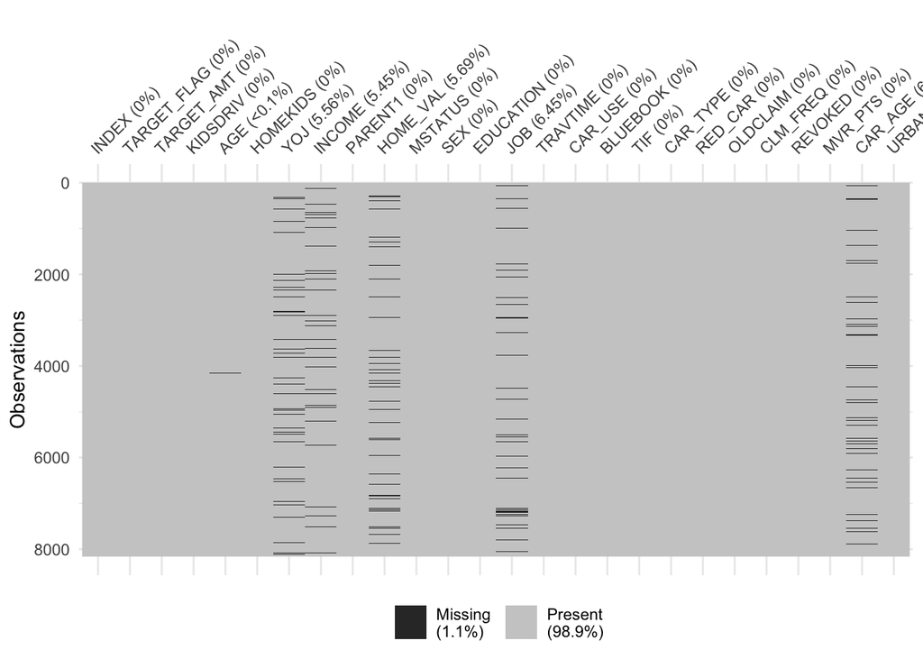

## Data Preperation

As revealed earlier there were a list of columns that we factors that should be integers. We start by converting the columns to numeric.

```
## Observations: 8,161
## Variables: 5
## $ INCOME   <fct> "$67,349", "$91,449", "$16,039", NA, "$114,986", "$125,…
## $ HOME_VAL <fct> "$0", "$257,252", "$124,191", "$306,251", "$243,925", "…
## $ JOB      <fct> Professional, z_Blue Collar, Clerical, z_Blue Collar, D…
## $ BLUEBOOK <fct> "$14,230", "$14,940", "$4,010", "$15,440", "$18,000", "…
## $ OLDCLAIM <fct> "$4,461", "$0", "$38,690", "$0", "$19,217", "$0", "$0",…
```

```
## Observations: 8,161
## Variables: 5
## $ INCOME   <dbl> 5032, 6291, 1249, NA, 508, 745, 1487, 314, 4764, 281, 5…
## $ HOME_VAL <dbl> 1, 3258, 347, 3916, 3033, 1, NA, 4166, 1, 1, 1, 2261, 1…
## $ JOB      <dbl> 6, 8, 1, 8, 2, 8, 8, 8, 1, 6, 4, 6, 5, NA, 3, 1, 4, 4, …
## $ BLUEBOOK <dbl> 434, 503, 2212, 553, 802, 746, 2672, 701, 135, 852, 831…
## $ OLDCLAIM <dbl> 1449, 1, 1311, 1, 432, 1, 1, 510, 1, 1, 1, 1, 1727, 1, …
```

Both boxplot and summary stats with the square root transform of Home_val and Income to confirm we can use median or mean values to replace NA values if we chose.

[figure not shown]

```
##          vars    n    mean      sd median trimmed     mad min  max range
## AGE         1 8155   44.79    8.63   45.0   44.83    8.90  16   81    65
## YOJ         2 7707   10.50    4.09   11.0   11.07    2.97   0   23    23
## INCOME      3 7716 3040.33 2029.52 3024.5 3018.56 2647.18   1 6612  6611
## HOME_VAL    4 7697 1785.40 1695.15 1459.0 1639.68 2161.63   1 5106  5105
## JOB         5 7635    5.01    2.46    5.0    5.14    2.97   1    8     7
## CAR_AGE     6 7651    8.33    5.70    8.0    7.96    7.41  -3   28    31
##           skew kurtosis    se
## AGE      -0.03    -0.06  0.10
## YOJ      -1.20     1.18  0.05
## INCOME    0.04    -1.24 23.10
## HOME_VAL  0.43    -1.24 19.32
## JOB      -0.34    -1.16  0.03
## CAR_AGE   0.28    -0.75  0.07
```

We next replace all NA values with mean values for cases that are missing values and rerun sapply function to confirm there are no longer any missing values.

```
##       INDEX TARGET_FLAG  TARGET_AMT    KIDSDRIV         AGE    HOMEKIDS
##           0           0           0           0           0           0
##         YOJ      INCOME     PARENT1    HOME_VAL     MSTATUS         SEX
##           0           0           0           0           0           0
##   EDUCATION         JOB    TRAVTIME     CAR_USE    BLUEBOOK         TIF
##           0           0           0           0           0           0
##    CAR_TYPE     RED_CAR    OLDCLAIM    CLM_FREQ     REVOKED     MVR_PTS
##           0           0           0           0           0           0
##     CAR_AGE  URBANICITY
##           0           0
```

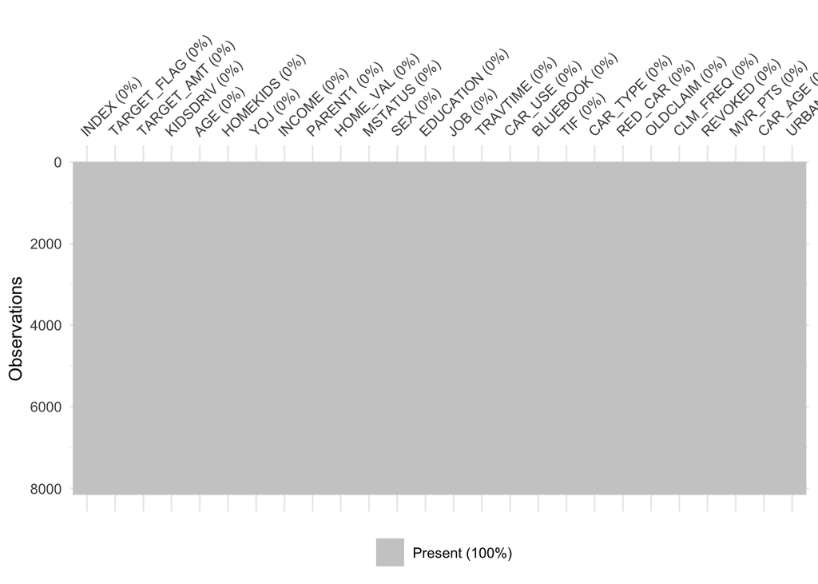

```
##          vars    n    mean      sd  median trimmed     mad min  max range
## AGE         1 8161   44.79    8.62   45.00   44.83    8.90  16   81    65
## YOJ         2 8161   10.50    3.98   11.00   11.05    2.97   0   23    23
## INCOME      3 8161 3040.33 1973.41 3040.33 3020.15 2492.74   1 6612  6611
## HOME_VAL    4 8161 1785.40 1646.25 1680.00 1642.31 2489.29   1 5106  5105
## JOB         5 8161    5.01    2.38    5.01    5.14    2.95   1    8     7
## CAR_AGE     6 8161    8.33    5.52    8.33    7.98    5.44  -3   28    31
##           skew kurtosis    se
## AGE      -0.03    -0.06  0.10
## YOJ      -1.24     1.42  0.04
## INCOME    0.05    -1.14 21.84
## HOME_VAL  0.44    -1.14 18.22
## JOB      -0.36    -1.03  0.03
## CAR_AGE   0.29    -0.60  0.06
```

## Build Model

```
##
## Call:
## glm(formula = TARGET_FLAG ~ . - INDEX - TARGET_FLAG - TARGET_AMT,
##     family = binomial(link = "logit"), data = InsTrain)
##
## Deviance Residuals:
##     Min       1Q   Median       3Q      Max
## -2.5922  -0.7276  -0.4209   0.6419   3.1555
##
## Coefficients:
##                                   Estimate Std. Error z value Pr(>|z|)
## (Intercept)                     -4.709e-01  2.687e-01  -1.753 0.079675 .
## KIDSDRIV                         3.641e-01  6.053e-02   6.014 1.81e-09 ***
## AGE                             -4.635e-03  3.910e-03  -1.185 0.235876
## HOMEKIDS                         7.217e-02  3.651e-02   1.977 0.048085 *
## YOJ                             -2.674e-02  7.937e-03  -3.369 0.000755 ***
## INCOME                          -2.314e-05  1.662e-05  -1.392 0.163862
## PARENT1Yes                       3.497e-01  1.082e-01   3.232 0.001229 **
## HOME_VAL                        -9.899e-05  2.047e-05  -4.836 1.33e-06 ***
## MSTATUSz_No                      4.804e-01  7.717e-02   6.226 4.80e-10 ***
## SEXz_F                          -2.579e-01  1.021e-01  -2.526 0.011524 *
## EDUCATIONBachelors              -6.887e-01  1.043e-01  -6.603 4.03e-11 ***
## EDUCATIONMasters                -7.923e-01  1.291e-01  -6.136 8.47e-10 ***
## EDUCATIONPhD                    -1.026e+00  1.545e-01  -6.644 3.06e-11 ***
## EDUCATIONz_High School          -1.118e-01  9.212e-02  -1.214 0.224900
## JOB                             -2.270e-02  1.406e-02  -1.615 0.106418
## TRAVTIME                         1.517e-02  1.868e-03   8.121 4.62e-16 ***
## CAR_USEPrivate                  -8.701e-01  8.207e-02 -10.602  < 2e-16 ***
## BLUEBOOK                         2.106e-05  3.344e-05   0.630 0.528975
## TIF                             -5.453e-02  7.276e-03  -7.495 6.63e-14 ***
## CAR_TYPEPanel Truck              6.109e-02  1.364e-01   0.448 0.654173
## CAR_TYPEPickup                   5.281e-01  1.006e-01   5.249 1.53e-07 ***
## CAR_TYPESports Car               1.209e+00  1.217e-01   9.934  < 2e-16 ***
## CAR_TYPEVan                      3.726e-01  1.195e-01   3.119 0.001815 **
## CAR_TYPEz_SUV                    9.618e-01  1.024e-01   9.392  < 2e-16 ***
## RED_CARyes                       1.440e-03  8.558e-02   0.017 0.986572
## OLDCLAIM                         8.744e-05  4.214e-05   2.075 0.037989 *
## CLM_FREQ                         1.161e-01  3.190e-02   3.639 0.000274 ***
## REVOKEDYes                       7.483e-01  7.965e-02   9.395  < 2e-16 ***
## MVR_PTS                          1.101e-01  1.360e-02   8.092 5.86e-16 ***
## CAR_AGE                         -6.893e-04  7.459e-03  -0.092 0.926369
## URBANICITYz_Highly Rural/ Rural -2.281e+00  1.122e-01 -20.331  < 2e-16 ***
## ---
## Signif. codes:  0 '***' 0.001 '**' 0.01 '*' 0.05 '.' 0.1 ' ' 1
##
## (Dispersion parameter for binomial family taken to be 1)
##
##     Null deviance: 9418.0  on 8160  degrees of freedom
## Residual deviance: 7422.7  on 8130  degrees of freedom
## AIC: 7484.7
##
## Number of Fisher Scoring iterations: 5
```